# (Prosper Loan Data)

## Preliminary Wrangling

Prosper Marketplace is America's first peer-to-peer lending marketplace, with over $7 billion in funded loans,

Borrowers request personal loans on Prosper and investors (individual or institutional) can fund anywhere from USD 2000 to USD 40000 per loan request.

Investors can consider borrowers’ credit scores, ratings, and histories and the category of the loan. Prosper handles the servicing of the loan and collects and distributes borrower payments and interest back to the loan investors. [wikipedia source link](https://en.wikipedia.org/wiki/Prosper_Marketplace#:~:text=10%20External%20links-,Overview,to%20%2440%2C000%20per%20loan%20request.)

> This data set contains 113,937 loans with 81 variables on each loan, including loan amount, borrower rate (or interest rate), current loan status, borrower income, and many others.(Last updated 03/11/2014)

> This data [dictionary](https://docs.google.com/spreadsheets/d/1gDyi_L4UvIrLTEC6Wri5nbaMmkGmLQBk-Yx3z0XDEtI/edit#gid=0) explains the variables in the data set.

```python
# import all packages and set plots to be embedded inline
import numpy as np
import pandas as pd
import matplotlib.pyplot as plt
import seaborn as sb

%matplotlib inline
```

```python
# Reading the CSV file
df = pd.read_csv('prosperLoanData.csv')
pd.set_option('display.max_columns', 81)
df.head(5)
```

|  | ListingKey | ListingNumber | ListingCreationDate | CreditGrade | Term | LoanStatus | ClosedDate | BorrowerAPR | BorrowerRate | LenderYield | EstimatedEffectiveYield | EstimatedLoss | EstimatedReturn | ProsperRating (numeric) | ProsperRating (Alpha) | ProsperScore | ListingCategory (numeric) | BorrowerState | Occupation | EmploymentStatus | EmploymentStatusDuration | IsBorrowerHomeowner | CurrentlyInGroup | GroupKey | DateCreditPulled | CreditScoreRangeLower | CreditScoreRangeUpper | FirstRecordedCreditLine | CurrentCreditLines | … |
| --- | --- | --- | --- | --- | --- | --- | --- | --- | --- | --- | --- | --- | --- | --- | --- | --- | --- | --- | --- | --- | --- | --- | --- | --- | --- | --- | --- | --- | --- | --- |
| 0 | 1021339766868145413AB3B | 193129 | 2007-08-26 19:09:29.263000000 | C | 36 | Completed | 2009-08-14 00:00:00 | 0.16516 | 0.1580 | 0.1380 | NaN | NaN | NaN | NaN | NaN | NaN | 0 | CO | Other | Self-employed | 2.0 | True | True | NaN | 2007-08-26 18:41:46.780000000 | 640.0 | 659.0 | 2001-10-11 00:00:00 | 5.0 | … |
| 1 | 10273602499503308B223C1 | 1209647 | 2014-02-27 08:28:07.900000000 | NaN | 36 | Current | NaN | 0.12016 | 0.0920 | 0.0820 | 0.07960 | 0.0249 | 0.05470 | 6.0 | A | 7.0 | 2 | CO | Professional | Employed | 44.0 | False | False | NaN | 2014-02-27 08:28:14 | 680.0 | 699.0 | 1996-03-18 00:00:00 | 14.0 | … |
| 2 | 0EE9337825851032864889A | 81716 | 2007-01-05 15:00:47.090000000 | HR | 36 | Completed | 2009-12-17 00:00:00 | 0.28269 | 0.2750 | 0.2400 | NaN | NaN | NaN | NaN | NaN | NaN | 0 | GA | Other | Not available | NaN | False | True | 783C3371218786870A73D20 | 2007-01-02 14:09:10.060000000 | 480.0 | 499.0 | 2002-07-27 00:00:00 | NaN | … |
| 3 | 0EF5356002482715299901A | 658116 | 2012-10-22 11:02:35.010000000 | NaN | 36 | Current | NaN | 0.12528 | 0.0974 | 0.0874 | 0.08490 | 0.0249 | 0.06000 | 6.0 | A | 9.0 | 16 | GA | Skilled Labor | Employed | 113.0 | True | False | NaN | 2012-10-22 11:02:32 | 800.0 | 819.0 | 1983-02-28 00:00:00 | 5.0 | … |
| 4 | 0F023589499656230C5E3E2 | 909464 | 2013-09-14 18:38:39.097000000 | NaN | 36 | Current | NaN | 0.24614 | 0.2085 | 0.1985 | 0.18316 | 0.0925 | 0.09066 | 3.0 | D | 4.0 | 2 | MN | Executive | Employed | 44.0 | True | False | NaN | 2013-09-14 18:38:44 | 680.0 | 699.0 | 2004-02-20 00:00:00 | 19.0 | … |

```python
# Structure of the Dataset
df.shape
```

```
(113937, 81)
```

```python
# Checking for dataset null values and datatypes
df.info()
```

```
<class 'pandas.core.frame.DataFrame'>
RangeIndex: 113937 entries, 0 to 113936
Data columns (total 81 columns):
 #   Column                               Non-Null Count   Dtype
---  ------                               --------------   -----
 0   ListingKey                           113937 non-null  object
 1   ListingNumber                        113937 non-null  int64
 2   ListingCreationDate                  113937 non-null  object
 3   CreditGrade                          28953 non-null   object
 4   Term                                 113937 non-null  int64
 5   LoanStatus                           113937 non-null  object
 6   ClosedDate                           55089 non-null   object
 7   BorrowerAPR                          113912 non-null  float64
 8   BorrowerRate                         113937 non-null  float64
 9   LenderYield                          113937 non-null  float64
```

[output cut: 73 more lines]

```python
#checking statistics of dataframe
pd.set_option('display.max_columns', 61)
df.describe()
```

|  | ListingNumber | Term | BorrowerAPR | BorrowerRate | LenderYield | EstimatedEffectiveYield | EstimatedLoss | EstimatedReturn | ProsperRating (numeric) | ProsperScore | ListingCategory (numeric) | EmploymentStatusDuration | CreditScoreRangeLower | CreditScoreRangeUpper | CurrentCreditLines | OpenCreditLines | TotalCreditLinespast7years | OpenRevolvingAccounts | OpenRevolvingMonthlyPayment | InquiriesLast6Months | TotalInquiries | CurrentDelinquencies | AmountDelinquent | DelinquenciesLast7Years | PublicRecordsLast10Years | PublicRecordsLast12Months | RevolvingCreditBalance | BankcardUtilization | AvailableBankcardCredit | … |
| --- | --- | --- | --- | --- | --- | --- | --- | --- | --- | --- | --- | --- | --- | --- | --- | --- | --- | --- | --- | --- | --- | --- | --- | --- | --- | --- | --- | --- | --- | --- |
| count | 1.139370e+05 | 113937.000000 | 113912.000000 | 113937.000000 | 113937.000000 | 84853.000000 | 84853.000000 | 84853.000000 | 84853.000000 | 84853.000000 | 113937.000000 | 106312.000000 | 113346.000000 | 113346.000000 | 106333.000000 | 106333.000000 | 113240.000000 | 113937.00000 | 113937.000000 | 113240.000000 | 112778.000000 | 113240.000000 | 106315.000000 | 112947.000000 | 113240.000000 | 106333.000000 | 1.063330e+05 | 106333.000000 | 106393.000000 | … |
| mean | 6.278857e+05 | 40.830248 | 0.218828 | 0.192764 | 0.182701 | 0.168661 | 0.080306 | 0.096068 | 4.072243 | 5.950067 | 2.774209 | 96.071582 | 685.567731 | 704.567731 | 10.317192 | 9.260164 | 26.754539 | 6.96979 | 398.292161 | 1.435085 | 5.584405 | 0.592052 | 984.507059 | 4.154984 | 0.312646 | 0.015094 | 1.759871e+04 | 0.561309 | 11210.225447 | … |
| std | 3.280762e+05 | 10.436212 | 0.080364 | 0.074818 | 0.074516 | 0.068467 | 0.046764 | 0.030403 | 1.673227 | 2.376501 | 3.996797 | 94.480605 | 66.458275 | 66.458275 | 5.457866 | 5.022644 | 13.637871 | 4.63097 | 447.159711 | 2.437507 | 6.429946 | 1.978707 | 7158.270157 | 10.160216 | 0.727868 | 0.154092 | 3.293640e+04 | 0.317918 | 19818.361309 | … |
| min | 4.000000e+00 | 12.000000 | 0.006530 | 0.000000 | -0.010000 | -0.182700 | 0.004900 | -0.182700 | 1.000000 | 1.000000 | 0.000000 | 0.000000 | 0.000000 | 19.000000 | 0.000000 | 0.000000 | 2.000000 | 0.00000 | 0.000000 | 0.000000 | 0.000000 | 0.000000 | 0.000000 | 0.000000 | 0.000000 | 0.000000 | 0.000000e+00 | 0.000000 | 0.000000 | … |
| 25% | 4.009190e+05 | 36.000000 | 0.156290 | 0.134000 | 0.124200 | 0.115670 | 0.042400 | 0.074080 | 3.000000 | 4.000000 | 1.000000 | 26.000000 | 660.000000 | 679.000000 | 7.000000 | 6.000000 | 17.000000 | 4.00000 | 114.000000 | 0.000000 | 2.000000 | 0.000000 | 0.000000 | 0.000000 | 0.000000 | 0.000000 | 3.121000e+03 | 0.310000 | 880.000000 | … |
| 50% | 6.005540e+05 | 36.000000 | 0.209760 | 0.184000 | 0.173000 | 0.161500 | 0.072400 | 0.091700 | 4.000000 | 6.000000 | 1.000000 | 67.000000 | 680.000000 | 699.000000 | 10.000000 | 9.000000 | 25.000000 | 6.00000 | 271.000000 | 1.000000 | 4.000000 | 0.000000 | 0.000000 | 0.000000 | 0.000000 | 0.000000 | 8.549000e+03 | 0.600000 | 4100.000000 | … |
| 75% | 8.926340e+05 | 36.000000 | 0.283810 | 0.250000 | 0.240000 | 0.224300 | 0.112000 | 0.116600 | 5.000000 | 8.000000 | 3.000000 | 137.000000 | 720.000000 | 739.000000 | 13.000000 | 12.000000 | 35.000000 | 9.00000 | 525.000000 | 2.000000 | 7.000000 | 0.000000 | 0.000000 | 3.000000 | 0.000000 | 0.000000 | 1.952100e+04 | 0.840000 | 13180.000000 | … |
| max | 1.255725e+06 | 60.000000 | 0.512290 | 0.497500 | 0.492500 | 0.319900 | 0.366000 | 0.283700 | 7.000000 | 11.000000 | 20.000000 | 755.000000 | 880.000000 | 899.000000 | 59.000000 | 54.000000 | 136.000000 | 51.00000 | 14985.000000 | 105.000000 | 379.000000 | 83.000000 | 463881.000000 | 99.000000 | 38.000000 | 20.000000 | 1.435667e+06 | 5.950000 | 646285.000000 | … |

### What is the structure of your dataset?

> The data contains 113937 observations and 81 columns, most variables (61 features) are numeric, and 20 object, bool or categorical features

### What is/are the main feature(s) of interest in your dataset?

> Investigating factors affecting borrower’s APR or interest rate, and loan’s outcome status

### What features in the dataset do you think will help support your investigation into your feature(s) of interest?

> I Suggested some of the following features would have an impact on the Borrower’s APR and the Loan Status: such as :Loan Original Amount, Prosper Score, Income Range, Borrower's Occupation, Employment Status, Credit Grade,Credit Score Range, term of the loan in months, Monthly Loan Payment.

## Univariate Exploration

```python
# Checking stats for BorrowerAPR variable
df.BorrowerAPR.describe()
```

```
count    113912.000000
mean          0.218828
std           0.080364
min           0.006530
25%           0.156290
50%           0.209760
75%           0.283810
max           0.512290
Name: BorrowerAPR, dtype: float64
```

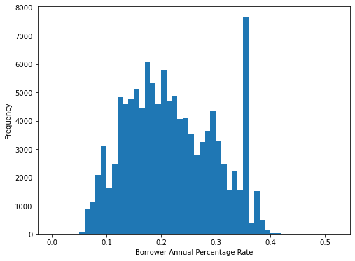

```python
# plotting a histogram of the BorrowerAPR variable
bins = np.arange(0, df['BorrowerAPR'].max()+ 0.01 ,  0.01)
plt.figure(figsize=[8,6])
plt.hist(data=df, x= 'BorrowerAPR', bins = bins)
plt.xlabel('Borrower Annual Percentage Rate')
plt.ylabel('Frequency');
```

```python
# checking value counts for BorrowerAPR variable
df.BorrowerAPR.value_counts(bins=11)
```

```
(0.144, 0.19]        23972
(0.19, 0.236]        22417
(0.0985, 0.144]      15729
(0.236, 0.282]       15701
(0.282, 0.328]       14694
(0.328, 0.374]       12177
(0.0525, 0.0985]      7082
(0.374, 0.42]         2090
(0.00502, 0.0525]       43
(0.42, 0.466]            4
(0.466, 0.512]           3
Name: BorrowerAPR, dtype: int64
```

> Borrower Annual Percentage Rate seem to have a normal distibution between the values above 0.01 and hair above 0.3 then an interesting high peak between 0.32 and 0.37 %, next I'll check loan status as the next variable.

```python
# Checking stats for Loan status categorical variable
df.LoanStatus.describe()
```

```
count      113937
unique         12
top       Current
freq        56576
Name: LoanStatus, dtype: object
```

```python
# Checking Loan status categorical variable value counts
df.LoanStatus.value_counts()
```

```
Current                   56576
Completed                 38074
Chargedoff                11992
Defaulted                  5018
Past Due (1-15 days)        806
Past Due (31-60 days)       363
Past Due (61-90 days)       313
Past Due (91-120 days)      304
Past Due (16-30 days)       265
FinalPaymentInProgress      205
Past Due (>120 days)         16
Cancelled                     5
Name: LoanStatus, dtype: int64
```

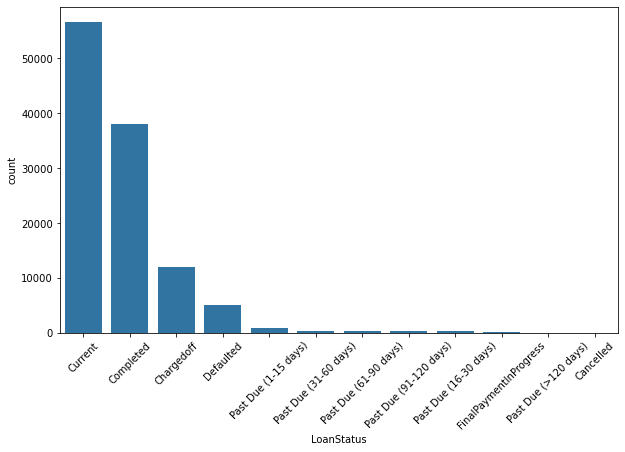

```python
# plotting a bar graph for the loan status variable
base_color=sb.color_palette()[0]
plt.figure(figsize=[10,6])
sb.countplot(data=df, x='LoanStatus',order= df.LoanStatus.value_counts().index, color=base_color)
plt.xticks(rotation = 45);
```

> The 3 most frequent loan status values are the current (Top Value) then comes the completed status and charged off(means that the original creditor has given up on being repaid according to the original terms of the loan. It considers the remaining balance to be bad debt) then the defaulted status loan.

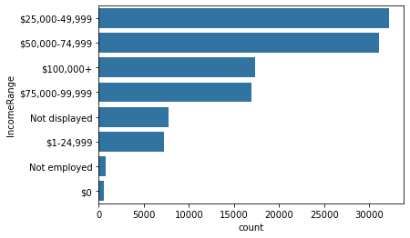

```python
 # Checking Income range
sb.countplot(data=df, y='IncomeRange', order=df.IncomeRange.value_counts().index, color=base_color)
plt.show()
```

> Most borrowers have an income range between 25K and 75K USD

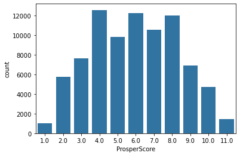

```python
# 2nd Prosper Score (categorical) variable
sb.countplot(data=df, x='ProsperScore', color=base_color)
```

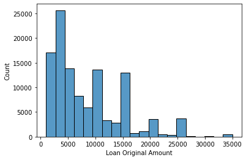

```python
#3rd plotting a histogram of Loan orignial amount Variable
sb.histplot(df['LoanOriginalAmount'], bins=20)
plt.xlabel('Loan Original Amount');
```

> The distribution of the Loan Original Amount is right skewed where the highest values are between > 1K and 15K, then a sudden drop above 15K with very little values on the right.

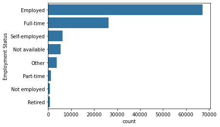

```python
#plotting a barplot for the Employment Status
sb.countplot(data = df, y= 'EmploymentStatus', color = base_color, order=df['EmploymentStatus'].value_counts().index)
plt.ylabel('Employment Status')
plt.show()
```

> Employed borrowers and full time employed have the highest count value among all the borrowers which seem to be logical, as their income is failry secured. less loans to the not-employed and retired people.

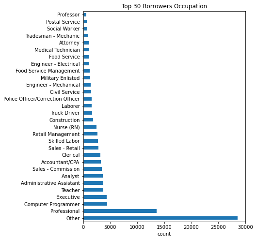

```python
# plotting a horizontal bar graph of the Borrower's Occupation
df['Occupation'].value_counts()[:30].plot(kind = 'barh', figsize=[6,8])
plt.xlabel('count')
plt.title('Top 30 Borrowers Occupation');
```

> Interesting that the highest count in occupation is not very informative (set to other), then comes Professional occupation

> assuming that regardless of the occupation, a borrower doesn't have to hold a specific occupation to get the loan.

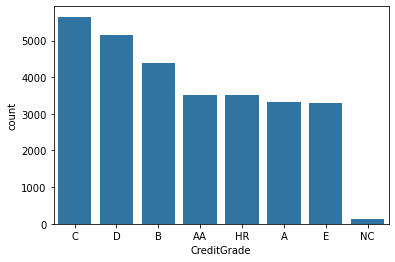

```python
# plotting credit grade of the borrowers
sb.countplot(data = df, x ='CreditGrade', order=df['CreditGrade'].value_counts().index, color=base_color);
```

> Loans are assigned a loan grade based on its interest rate. Each loan grade is associated with a modeled default range. The loan grades range from “AA”, which is the lowest modeled risk, to “E”, which is the highest modeled risk. so most loans have average score (C, D, B)

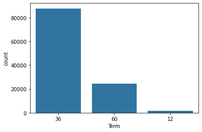

```python
# plotting a barplot for the term of the loan in months
sb.countplot(data = df, x = 'Term', color=base_color, order=df['Term'].value_counts().index);
```

> Most loans are 36 months Long, then 60 months and least value for shortest loan length of 12 months

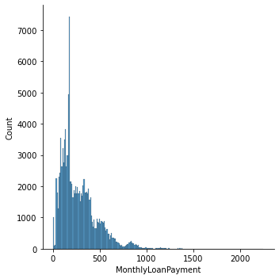

```python
#plotting a distribution plot for the Monthly Loan Payment
sb.displot(df['MonthlyLoanPayment'], kde=False);
```

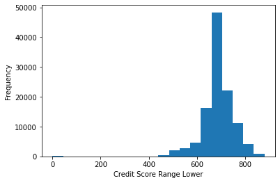

```python
# Plotting a histogram of the distribution of the Credit Score Range Lower
plt.hist(data=df, x='CreditScoreRangeLower', bins = 20)
plt.xlabel('Credit Score Range Lower')
plt.ylabel('Frequency');
```

```python
#Checking the ranges of the accepted Credit score using value_counts
df['CreditScoreRangeLower'].value_counts(bins=6 ,normalize=True)
```

```
(586.667, 733.333]    0.712894
(733.333, 880.0]      0.222544
(440.0, 586.667]      0.057839
(-0.881, 146.667]     0.001167
(293.333, 440.0]      0.000369
(146.667, 293.333]    0.000000
Name: CreditScoreRangeLower, dtype: float64
```

> The Credit Score Range seem to be normally distributed around 500 to 880 score, the higher the score the more liable for a borrower to get the loan, above 70% of the scores are higher than 580 score which is the fair score or the accepted one.

### Discuss the distribution(s) of your variable(s) of interest. Were there any unusual points? Did you need to perform any transformations?

> The Borrower’s APR variable took on a very small range of values, I had to assign a little value for the bins to watch the distribution. the data looked normally distributed except above the values 0.31 and between 0.36 there was a large peak

### Of the features you investigated, were there any unusual distributions? Did you perform any operations on the data to tidy, adjust, or change the form of the data? If so, why did you do this?

> Loan Original Amount was highly right skewed and had a number of outliers , I had to increase the number of bins in the original distribution to monitor closely the change in values of the loan amount, so loans above 25K are rarely given.

## Bivariate Exploration

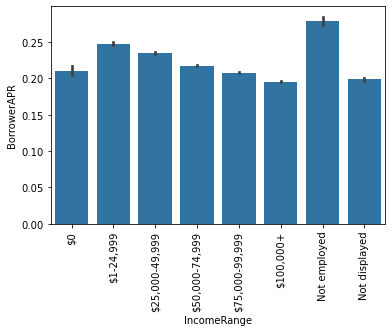

```python
# plotting a bar graph between income ranges and BorrowerAPR
order = ['$0','$1-24,999','$25,000-49,999','$50,000-74,999', '$75,000-99,999','$100,000+','Not employed','Not displayed']

sb.barplot(data=df, x='IncomeRange', y ='BorrowerAPR', color=base_color, order = order)
plt.xticks(rotation = 90);
```

> The higher the income range the less the rate applied on the loan, on the opposite side not employed category has the highest loan rate

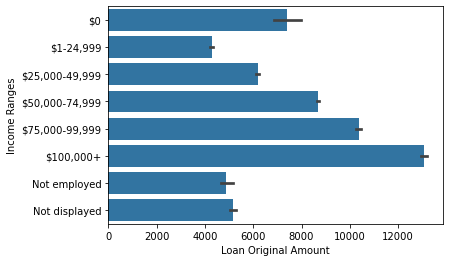

```python
# plotting a bar graph between income ranges and Loan Original Amount
sb.barplot(data=df, y='IncomeRange', x='LoanOriginalAmount', color=base_color, order=order)
plt.ylabel('Income Ranges')
plt.xlabel('Loan Original Amount');
```

> The highest income >75K has the highest loan amount on the opposite hand income < 25K has the Lowest loan amount

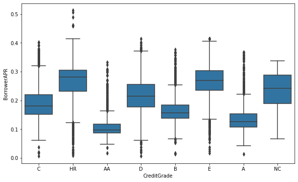

```python
# plotting a boxplot between BorrowerAPR and CreditGrade category
plt.figure(figsize=[10,6])
sb.boxplot(data=df, x='CreditGrade', y='BorrowerAPR', color=base_color);
```

> The AA score of credit grade (which is the highest score) has the least borrower rate on average, on the opposite hand the HR and E credit scores have the highest borrower rate

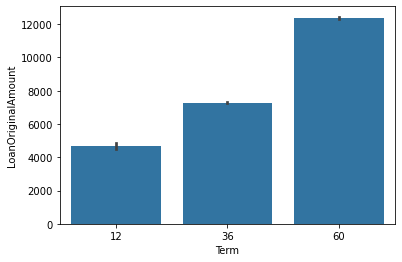

```python
#plotting the relathionship between BorrowerAPR and loan amount
sb.barplot(data=df, y='LoanOriginalAmount', x='Term', color=base_color);
```

> The highest loan amount is 60 months long, while the lowest loan amount are paid through 12 months term

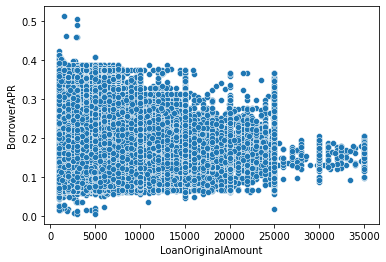

```python
#plotting the relathionship between BorrowerAPR and loan amount
sb.scatterplot(data=df, x='LoanOriginalAmount', y='BorrowerAPR', color=base_color);
```

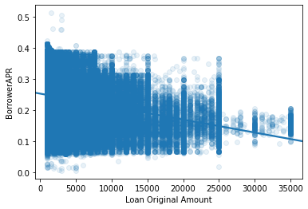

```python
# plotting a regplot for BorrowerAPR and Loan Original Amount
sb.regplot(data=df, x='LoanOriginalAmount', y='BorrowerAPR', x_jitter=0.3,scatter_kws = {'alpha':1/10}, truncate = False )
plt.xlabel('Loan Original Amount');
```

> So borrower APR is inversly proportional with the Loan Original Amount, the higher the loan value the less the rate applied.

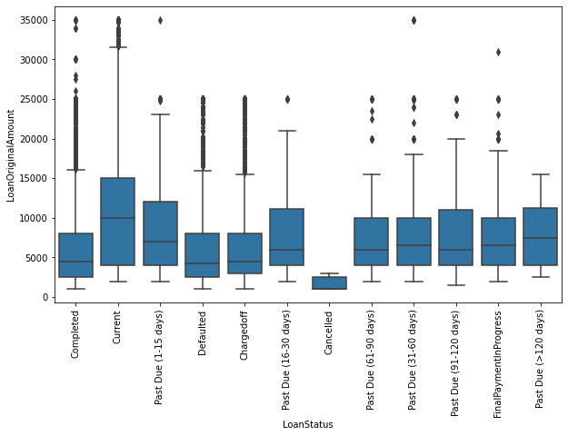

```python
#plotting the R/S between Loan amount and its status
plt.figure(figsize=[10,6])
sb.boxplot(data=df, y='LoanOriginalAmount', x='LoanStatus', color = base_color)
plt.xticks(rotation = 90);
```

> Most of the current loans are between 1K and 15K

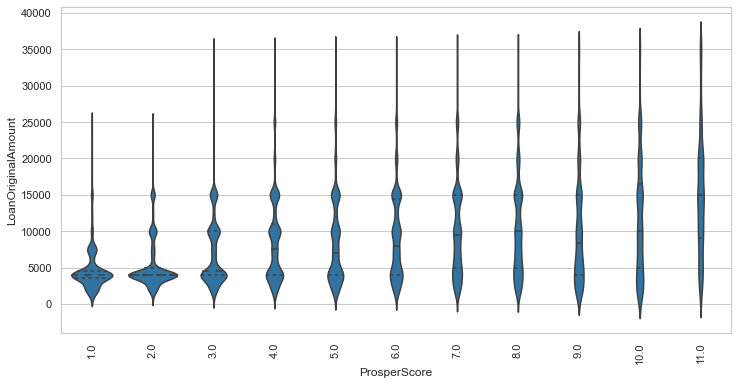

```python
#plotting the R/S between Loan amount and prosper score
sb.set(style="whitegrid")
plt.figure(figsize= [12,6])
sb.violinplot(data =df, x = 'ProsperScore', y = 'LoanOriginalAmount', inner = 'quartile', color = base_color)
plt.xticks(rotation = 90);
```

> The higher the prosper score the higher the range of the loan amount.

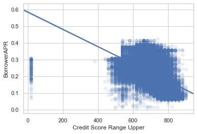

```python
# plotting a regplot for BorrowerAPR and CreditScoreRangeUpper
sb.regplot(data=df, x='CreditScoreRangeUpper', y='BorrowerAPR', x_jitter=0.3,scatter_kws = {'alpha':1/10}, truncate = False )
plt.xlabel('Credit Score Range Upper');
```

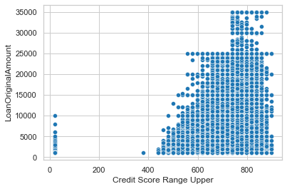

```python
# plotting a regplot for Loan Original Amount and Credit Score Range Upper
sb.scatterplot(data=df, x='CreditScoreRangeUpper', y='LoanOriginalAmount' ,color=base_color)
plt.xlabel('Credit Score Range Upper');
```

> Higher Credit score Ranges are associated with higher loan amounts and less loan rate applied.

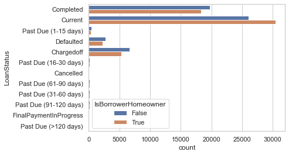

```python
#introducing a new variable (Is Borrower Home owner)
sb.countplot(data = df, y = 'LoanStatus', hue = 'IsBorrowerHomeowner');
```

> There's not much difference if the borrower is a home owner or not, it wont affect the loan status

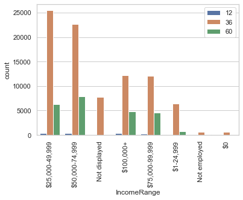

```python
# count plot for the income ranges and term of the loan in months
sb.countplot(data=df, x='IncomeRange', hue='Term')
plt.xticks(rotation =90)
plt.legend(loc='upper right');
```

> Most of the loans are 36 month in Term among the income ranges of 25k to 75k

### Talk about some of the relationships you observed in this part of the investigation. How did the feature(s) of interest vary with other features in the dataset?

> - Higher Income ranges, higher credit grade score positivly correlated with larger loan amount and less Borrowers APR
> - Longer Loan Term is also correlated with higher value for the loan amount
> - The most popular loan term is 36 months

### Did you observe any interesting relationships between the other features (not the main feature(s) of interest)?

> Credit Score Range is negatively correlated with BorrowerAPR and positively correlated with the loan amount.

> Also Borrower's occupation and whether or not the borrower is a home owner doesn't have that much impact on acquiring the loan.

## Multivariate Exploration

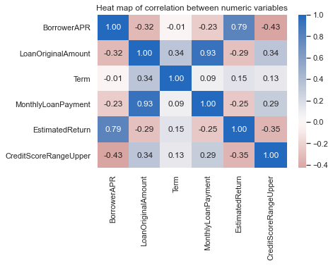

```python
# Plotting a heat map for some of the numeric variables of interest
X = df[['BorrowerAPR', 'LoanOriginalAmount', 'Term', 'MonthlyLoanPayment','EstimatedReturn',
        'CreditScoreRangeUpper']]
sb.heatmap(X.corr(), annot = True, fmt = '.2f', cmap = 'vlag_r', center = 0)
plt.title('Heat map of correlation between numeric variables');
```

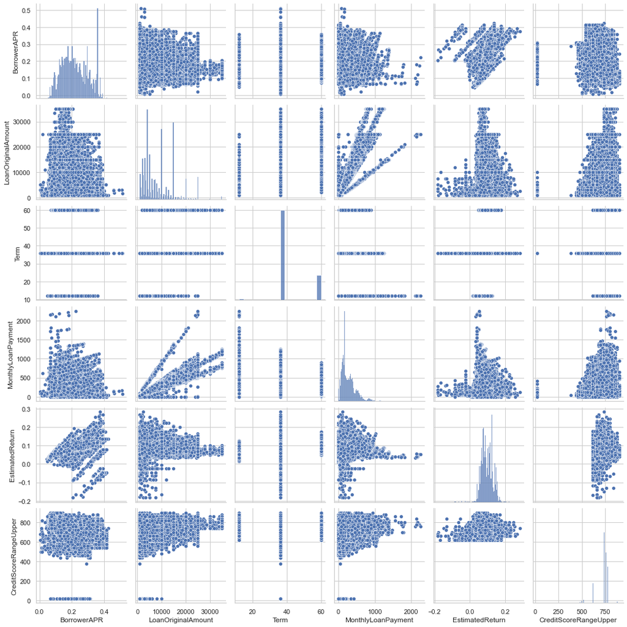

```python
# plotting a pairplot for numeric variables
g = sb.pairplot(data = df, vars = X);
```

> High direct correlation between Loan Original Amount and Monthly Loan Payment, then a fair correlation between Term and Loan Original Amount,

> and a negative relation between Loan Original Amount and Borrower's APR, also not surprisingly a high -ve relation between Credit Score Range and Borrower's APR, the higher the score the less the loan rate.

> The estimated return is highly correlated with the Borrower's APR, so the estimated return by dictionary definition is the return assigned to the listing at the time it was created. Estimated return is the difference between the Estimated Effective Yield and the Estimated Loss Rate. Applicable for loans originated after July 2009.

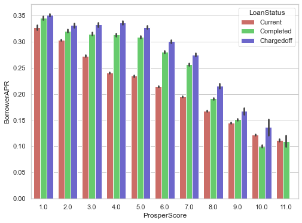

```python
# Plotting a plot for BorrowerAPR relation with prosper score given the loan status is current, completed or charged off
plt.figure(figsize=[8,6])
sb.barplot(data=df, x='ProsperScore', y='BorrowerAPR',  hue='LoanStatus',
           hue_order=['Current','Completed','Chargedoff'], palette='hls');
```

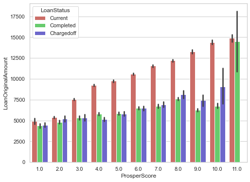

```python
# Plotting a barplot for Loan Original Amount relation with prosper score given the loan status is current, completed or charged off
plt.figure(figsize=[8,6])
sb.barplot(data=df, x='ProsperScore', y='LoanOriginalAmount',  hue='LoanStatus',
           hue_order=['Current','Completed','Chargedoff'], palette='hls');
```

> The highest charged off loans are among the poor ratings and its associated with higher BorrowerAPR, Also the highest Loan Original Amount are given to the higher prosper score with less probability of defaulting

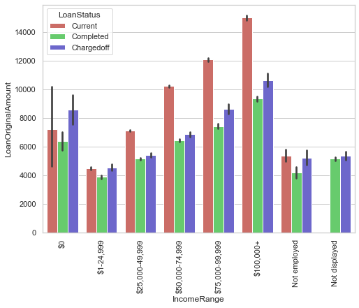

```python
# Plotting a barplot for Loan Original Amount relation with Income ranges given the loan status is current, completed or charged off
plt.figure(figsize=[8,6])
sb.barplot(data=df, x='IncomeRange',y='LoanOriginalAmount' ,hue='LoanStatus',
             hue_order=['Current','Completed','Chargedoff'], palette='hls', order=order)
plt.xticks(rotation = 90);
```

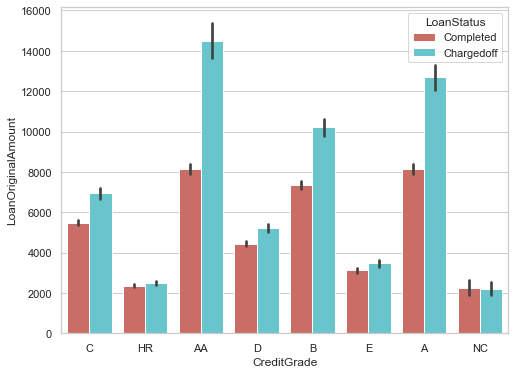

```python
# Plotting a barplot for Loan Original Amount relation with Cretid score given the loan status
# is completed or charged off
plt.figure(figsize=[8,6])
sb.barplot(data=df, x='CreditGrade',y='LoanOriginalAmount' ,hue='LoanStatus',
             hue_order=['Completed','Chargedoff'], palette='hls');
```

> Interesting, the highest charged off loans were among the AA credit score (the best credit score)

```python
#Checking the propotions for loan status variable
df['LoanStatus'].value_counts(normalize=True)
```

```
Current                   0.496555
Completed                 0.334167
Chargedoff                0.105251
Defaulted                 0.044042
Past Due (1-15 days)      0.007074
Past Due (31-60 days)     0.003186
Past Due (61-90 days)     0.002747
Past Due (91-120 days)    0.002668
Past Due (16-30 days)     0.002326
FinalPaymentInProgress    0.001799
Past Due (>120 days)      0.000140
Cancelled                 0.000044
Name: LoanStatus, dtype: float64
```

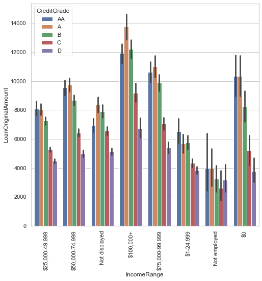

```python
# Plotting a barplot for Loan Original Amount relation with Income ranges
# given the credit grades between AA and D
plt.figure(figsize=[8,8])
sb.barplot(data=df, x='IncomeRange', y='LoanOriginalAmount',  hue='CreditGrade',
           hue_order=['AA','A','B', 'C', 'D'])
plt.xticks(rotation =90);
```

### Talk about some of the relationships you observed in this part of the investigation. Were there features that strengthened each other in terms of looking at your feature(s) of interest?

> I investigated more around the loan status variable and its relation with the loan original amount, borrowers APR, CreditGrade ,prosper score and IncomeRange

> Given that the Current and completed loans make up to %83 of all loans and the defaulted and charged off make about %15, there's a positive relation between charged off loans and BorrowerAPR

### Were there any interesting or surprising interactions between features?

> There was a surprise that the highest charged off loans were among the AA and A credit score (the best credit scores)